# Analysing Movie Genre Popularity with imdb Data

Lukas Heck

2018-09-02

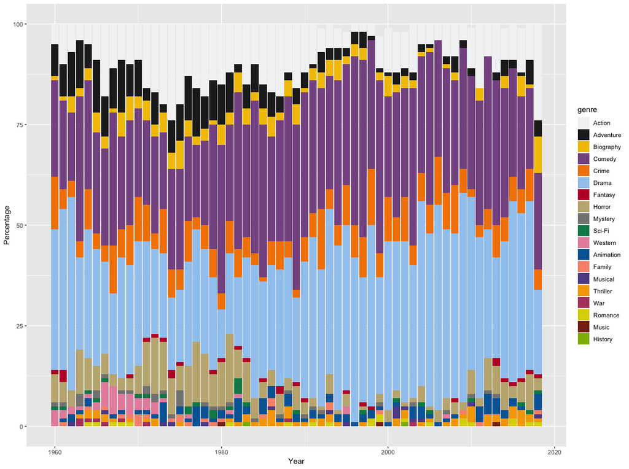

When it comes to hobbies, films and listening to podcasts / youtube videos of people talking about films is one of my favorites. For a while now, I was interested in approaching this hobby in a data-driven manner. I stumbled upon[this old rStudio blog post])https://blog.rstudio.com/2014/11/24/rvest-easy-web-scraping-with-r/) by none other than Hadley Wickham himself.

After reading it, I wanted to try web-scraping with selectorgadget myself and imdb seemed like a great place to start. I followed these questions: – how to extract data efficiently from imdb directly? – how can this information be used in a informative manner? – how can the selectorgadget-html output be easily understood?

After some time struggeling with exploring the selectorgadget-output, but [yet another blogpost](https://rstudio-pubs-static.s3.amazonaws.com/266430_f3fd4660b2744751ab144aa130768a06.html) was very helpful in helping to manage the basics. After a few attempts and some cleanup, I ended with:

```
library(rvest)
library(ROAuth)
library(tidyverse)


url <- 'https://www.imdb.com/search/title?count=100&release_date=1977,1977&title_type=feature&sort=moviemeter,asc'

# read html

imdb <- read_html(url)

genre_data_html <- html_nodes(imdb,'.genre')
title_data_html <- html_nodes(imdb,'.lister-item-header a')
title_data <- html_text(title_data_html)
genre_data <- html_text(genre_data_html)

title_data<-gsub("\n","",title_data)
title_data<-gsub(" ","",title_data)

genre_data<-gsub("\n","",genre_data)
genre_data<-gsub(" ","",genre_data)
genre_data<-gsub(",.*","",genre_data)




genre_data<-as.character(genre_data)
title_data<-as.character(title_data)
```

```
 head(genre_data)
[1] "Action"    "Drama"     "Action"    "Comedy"    "Drama"     "Animation"
```

```
head(title_data)
[1] "KriegderSterne"                    "UnheimlicheBegegnungderdrittenArt"
[3] "EinausgekochtesSchlitzohr"         "DerUntermieter"
[5] "NurSamstagNacht"                   "BernardundBianca-DieMäusepolizei"
```

So we can determine that in 1977, the year the first Star Wars movie came out, it was actually the most popular movie, followed by [Close Encounters of the Third Kind](https://www.imdb.com/title/tt0075860/?ref_=adv_li_tt). My first instinct was, okay, now I can create a chart for the popularity of a genre in a given year. But how can this be utilized further? Here is what I came up with:

```
yearly_fin <- data.frame()
for (y in (1960:2018)){
  url <- paste0("https://www.imdb.com/search/title?count=100&release_date=",y,",",y,"&title_type=feature&sort=boxoffice_gross_us,asc")
                imdb <- read_html(url)
                genre_data_html <- html_nodes(imdb,'.genre')
                title_data_html <- html_nodes(imdb,'.lister-item-header a')
                title_data <- html_text(title_data_html)
                genre_data <- html_text(genre_data_html)

                title_data<-gsub("\n","",title_data)
                title_data<-gsub(" ","",title_data)

                genre_data<-gsub("\n","",genre_data)
                genre_data<-gsub(" ","",genre_data)
                genre_data<-gsub(",.*","",genre_data)




                genre_data<-as.character(genre_data)
                title_data<-as.character(title_data)
if(length(genre_data) < 100){
  diff <- 100-length(genre_data)
  for (i in 1:diff)
    genre_data <- c(genre_data, as.character(i))
}

                yearly_data <- data.frame(title_data, genre_data)
                yearly_data$year <- y
                yearly_fin <- rbind(yearly_fin, yearly_data)
  print(y)
}
```

By just looping over the years in the underlying url, one can scrape the complete time-frame on a yearly basis in around 3 minutes (depending on your internet connection). Then, I used the output of `yearly_fin` to create this plot: [click here for the full-size](https://raw.githubusercontent.com/heck1/blog/master/static/images/imdb2.png)

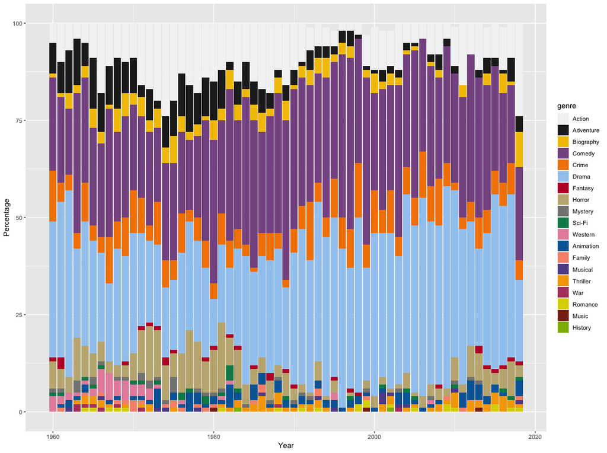